# Analysis of the Roller Coaster Data

Claire Moroney

2024-10-29

# Questions 1 and 2

1. Read the data file: Roller_Coasters_Data.csv. How many observations do we have in this data?

```
## [1] 145
```

there are 145 observations in this dataset.

# Question 3

3. Create a bar plot of Design of Roller Coasters. Use a few sentences to summarize your finding based on the plot

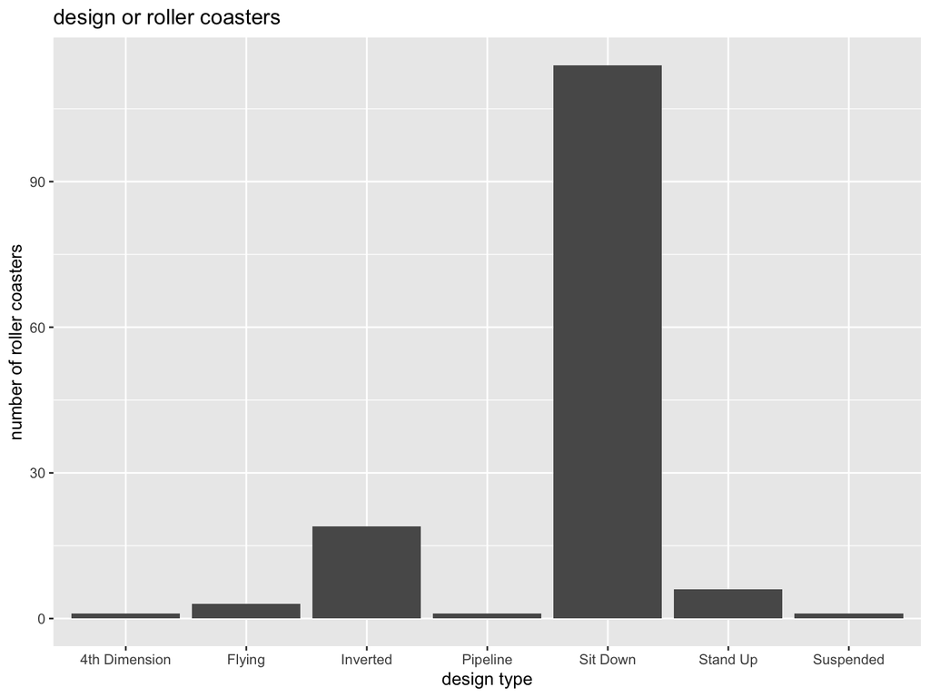

- The most common rollercoaster design is the sit-down rollercoaster.

# Question 4

4. Create a pie chart of Type of Roller Coasters. Use one sentence to summarize your finding based on the plot.

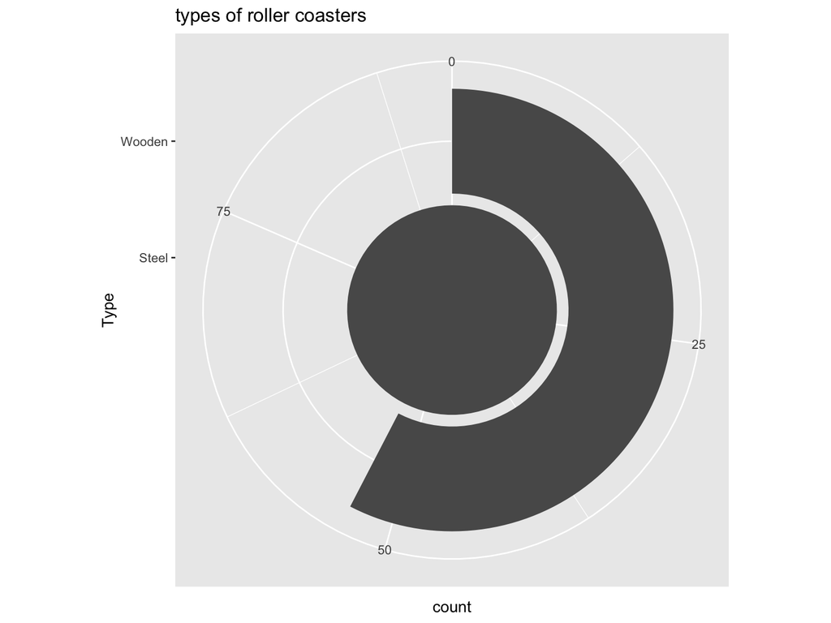

# Question 5

5. Create a histogram of Speed of Roller Coasters. Comment on the distribution of the histogram. You should focus on shape, center, spread, and if there are any unusual features.

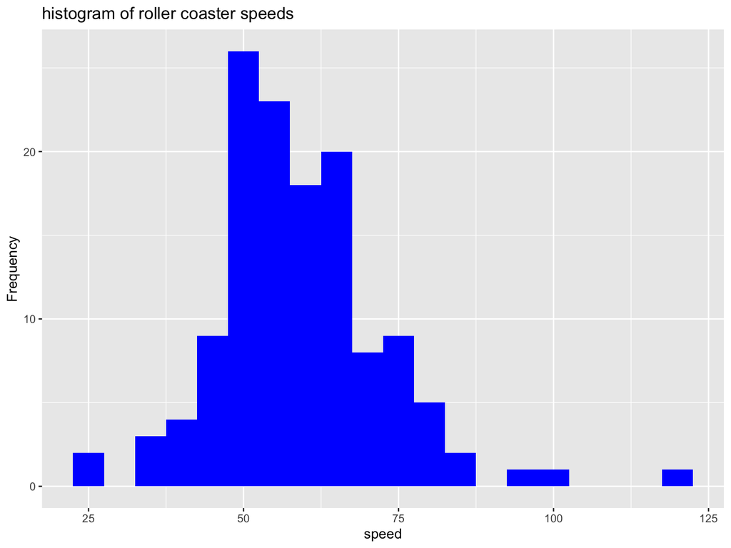

Most of the histograms have a speed of 50 mph to 75 mph. The distribution is slightly skewed to the right.

# Question 6

6. Create a boxplot of Speed by Design. Comment on the distributions of maximum speed among different designs of roller coasters.

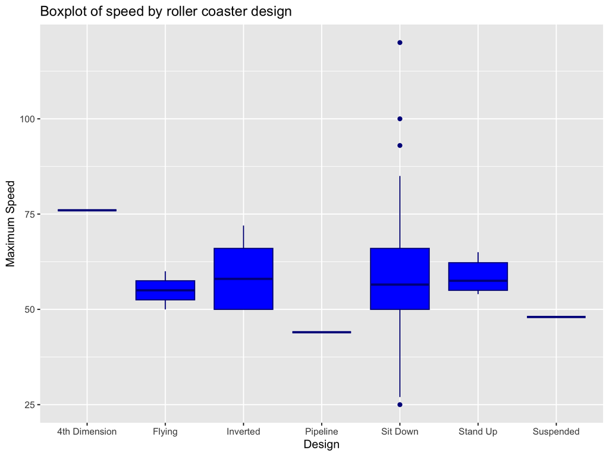

# Question 7

7. Create a boxplot of Speed by Age_Group. Comment on the distributions of maximum speed among different age groups of roller coasters.

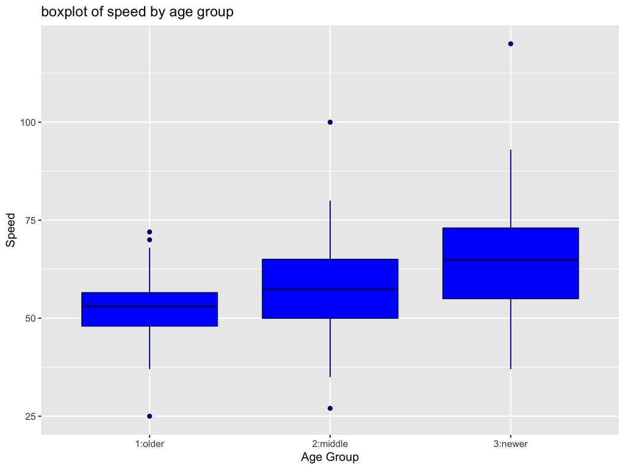

# Question 8

8. Create a scatterplot of Speed (y) against Height. Comment on the scatterplot. Create a scatterplot of Speed (y) against Drop Which variable (Height or Drop) is a better predictor of the maximum speed? Why?

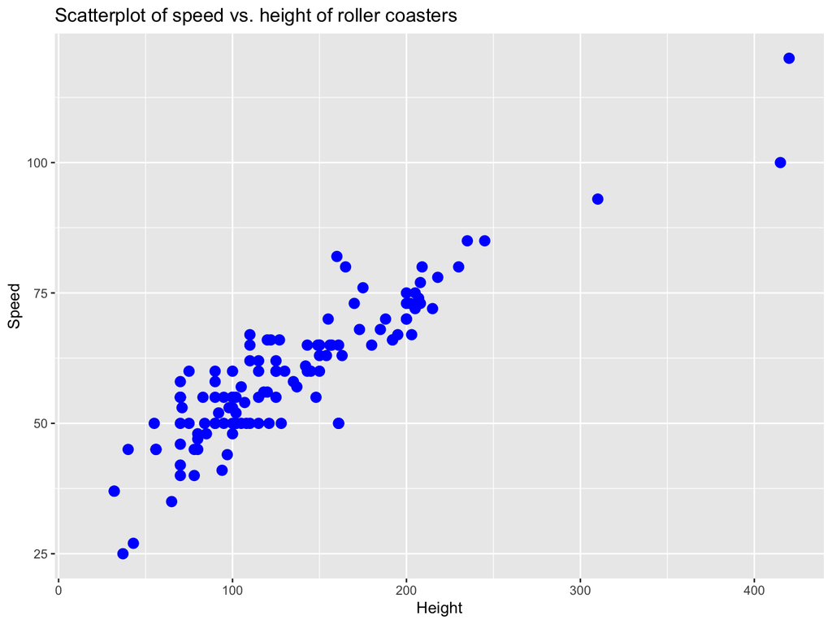

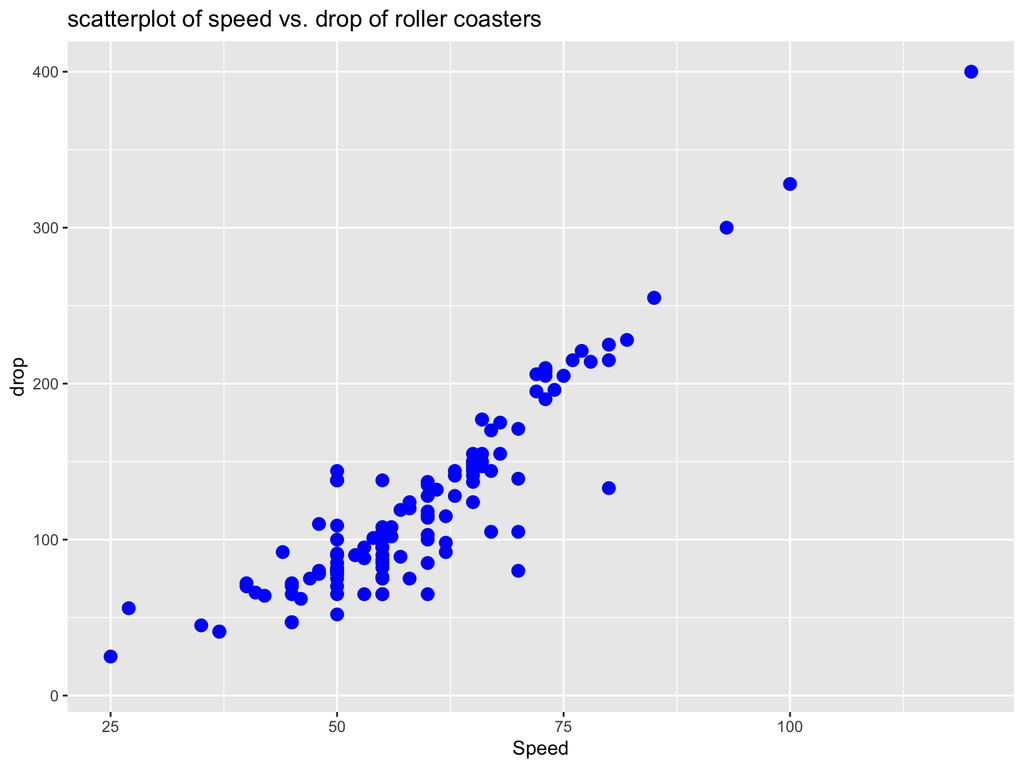

according to the first scatterplot, the variables height and speed have a strong, positive relationship.

according to the second scatterplot, the rollercoasters with the highest speeds also have a high drop. the two variables have a strong positive relationship